# Boosting based on Caret

Machine Learning

R code using Caret Package for Various Models of Boosting

Yeongeun Jeon , Jeongwook Lee , Jung In Seo  
11-01-2020

> Package `"caret"`은 다양한 머신러닝 분석을 하나로 모은 패키지이며, `trainControl`을 이용하여 과적합을 방지할 수 있다. `"caret"`에서는 Boosting을 이용한 다양한 기법을 수행할 수 있으며, 그 중 가장 많이 쓰이는 `AdaBoost`, `Gradient Boosting`, `XGBoost`를 이용하여 예제 데이터를 분석한다. 예제 데이터는 “Universal Bank_Main”로 유니버셜 은행의 고객들에 대한 데이터(출처 : Data Mining for Business Intelligence, Shmueli et al. 2010)이다. 데이터는 총 2500개이며, 변수의 갯수는 13개이다. 여기서 **Target**은 `Person.Loan`이다.

# **1. 데이터 불러오기**

```
pacman::p_load("data.table", "dplyr")

UB   <- fread(paste(getwd(),"Universal Bank_Main.csv", sep="/")) %>%   # 데이터 불러오기
  data.frame() %>%                                                     # Data frame 변환환
  mutate(Personal.Loan = ifelse(Personal.Loan==1, "yes","no")) %>%     # Character for classification
  select(-1)                                                           # ID변수 제거거



cols <- c("Family", "Education", "Personal.Loan", "Securities.Account",
          "CD.Account", "Online", "CreditCard")

UB   <- UB %>%
  mutate_at(cols, as.factor)                                          # 범주형 변수 변환

glimpse(UB)                                                           # 데이터 구조
```

```
Rows: 2,500
Columns: 13
$ Age                <int> 25, 45, 39, 35, 35, 37, 53, 50, 35, 34, 6~
$ Experience         <int> 1, 19, 15, 9, 8, 13, 27, 24, 10, 9, 39, 5~
$ Income             <int> 49, 34, 11, 100, 45, 29, 72, 22, 81, 180,~
$ ZIP.Code           <int> 91107, 90089, 94720, 94112, 91330, 92121,~
$ Family             <fct> 4, 3, 1, 1, 4, 4, 2, 1, 3, 1, 4, 3, 2, 4,~
$ CCAvg              <dbl> 1.6, 1.5, 1.0, 2.7, 1.0, 0.4, 1.5, 0.3, 0~
$ Education          <fct> 1, 1, 1, 2, 2, 2, 2, 3, 2, 3, 3, 2, 3, 2,~
$ Mortgage           <int> 0, 0, 0, 0, 0, 155, 0, 0, 104, 0, 0, 0, 0~
$ Personal.Loan      <fct> no, no, no, no, no, no, no, no, no, yes, ~
$ Securities.Account <fct> 1, 1, 0, 0, 0, 0, 0, 0, 0, 0, 0, 0, 1, 0,~
$ CD.Account         <fct> 0, 0, 0, 0, 0, 0, 0, 0, 0, 0, 0, 0, 0, 0,~
$ Online             <fct> 0, 0, 0, 0, 0, 1, 1, 0, 1, 0, 0, 1, 0, 1,~
$ CreditCard         <fct> 0, 0, 0, 0, 1, 0, 0, 1, 0, 0, 0, 0, 0, 0,~
```

# **2. 데이터 분할**

```
pacman::p_load("caret")
# Partition (Traning Data : Test Data = 7:3)
y      <- UB$Personal.Loan                       # Target

set.seed(200)
ind    <- createDataPartition(y, p=0.7, list=F)  # Training Data를 70% 추출
UB.trd <- UB[ind,]                               # Traning Data

UB.ted <- UB[-ind,]                              # Test Data
```

# **3. AdaBoost**

## **3-1. 최적의 모수 찾기**

> Boosting에서 가장 많이 쓰이는 AdaBoost의 최적의 모수를 찾기 위해서 `"Random Search"` 방법을 먼저 수행하였다.

```
fitControl <- trainControl(method = "cv", number = 5, search = "random")    # 5-Fold-Cross Validation
```

```
set.seed(100)                                                          # seed 고정 For Cross Validation
caret.rd.ada <- train(Personal.Loan~., data = UB.trd,
                      method = "AdaBoost.M1", trControl = fitControl,
                      tuneLength = 5)                                  # tuneLength (탐색할 후보 모수 갯수)

caret.rd.ada
```

```
AdaBoost.M1

1751 samples
  12 predictor
   2 classes: 'no', 'yes'

No pre-processing
Resampling: Cross-Validated (5 fold)
Summary of sample sizes: 1401, 1401, 1400, 1401, 1401
Resampling results across tuning parameters:

  coeflearn  maxdepth  mfinal  Accuracy   Kappa
  Breiman     7        70      0.9817338  0.8991055
  Freund      2        86      0.9800130  0.8871317
  Zhu         4        89      0.9817322  0.8972157
  Zhu         6        23      0.9828702  0.9035620
  Zhu        23        78      0.9823036  0.9001572

Accuracy was used to select the optimal model using the
 largest value.
The final values used for the model were mfinal = 23, maxdepth =
 6 and coeflearn = Zhu.
```

- Tune Parameter
  - `mfinal` : 반복 수
  - `maxdepth` : Tree의 최대 깊이
  - `coeflearn` : 가중치 업데이트 계수

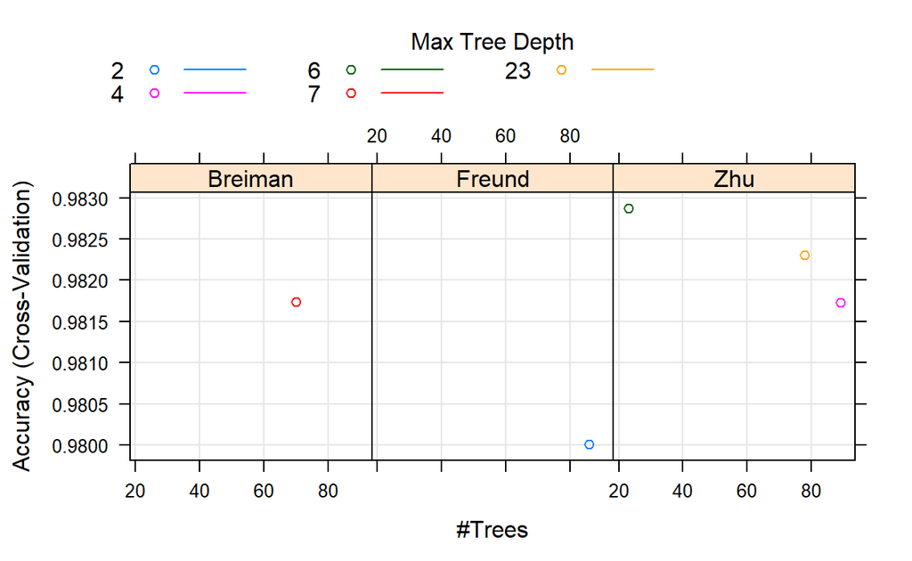

```
plot(caret.rd.ada)                            # Accuracy
```

- `maxdepth` = 6, `mfinal` = 23, `coeflearn` = “Zhu”일 때 정확도가 가장 높다.
- `mfinal` = 23을 기준으로 다양한 후보 모수를 주며 `Grid Search` 방법으로 최적의 모수를 찾는다.

[output not shown]

```
set.seed(100)  # seed 고정 For Cross Validation
caret.gd.ada <- train(Personal.Loan~., data = UB.trd, method = "AdaBoost.M1",
                      trControl = fitControl, tuneGrid = customGrid)

caret.gd.ada
```

```
AdaBoost.M1

1751 samples
  12 predictor
   2 classes: 'no', 'yes'

No pre-processing
Resampling: Cross-Validated (5 fold)
Summary of sample sizes: 1401, 1401, 1400, 1401, 1401
Resampling results across tuning parameters:

  mfinal  Accuracy   Kappa
  22      0.9371884  0.5745333
  23      0.9469011  0.6593923
  24      0.9457468  0.6272606

Tuning parameter 'maxdepth' was held constant at a value of 1

Tuning parameter 'coeflearn' was held constant at a value of Breiman
Accuracy was used to select the optimal model using the
 largest value.
The final values used for the model were mfinal = 23, maxdepth =
 1 and coeflearn = Breiman.
```

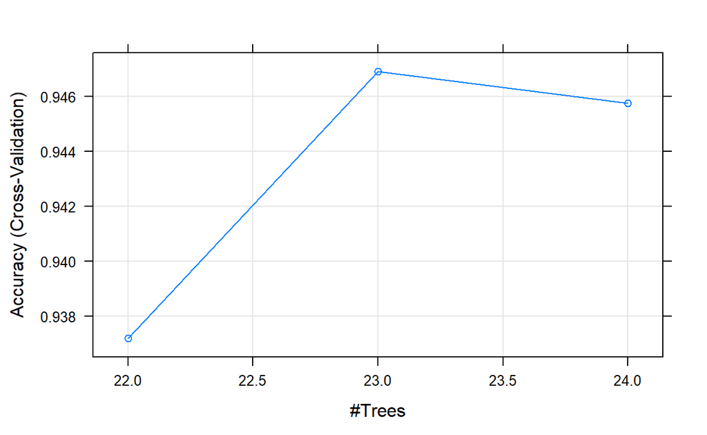

```
plot(caret.gd.ada)            # Accuracy
```

- `maxdepth` = 1, `mfinal` = 23, `coeflearn` = “Breiman”일 때 가장 높다.

### **3-1-1. 변수 중요도**

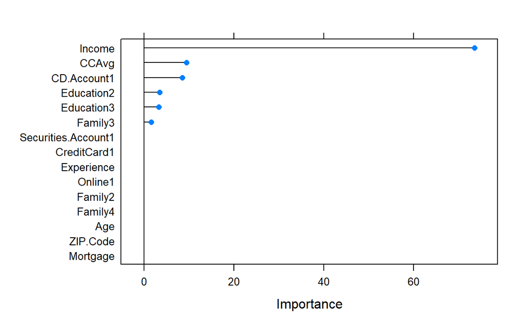

```
# 변수 중요도도
adaImp <- varImp(caret.gd.ada, scale = FALSE)
plot(adaImp)
```

### **3-1-2. 가중치**

```
caret.gd.ada$finalModel$weights             # 각 Tree에 대한 정보의 양양
```

```
 [1] 1.08325539 0.89957656 0.63275242 0.75226832 0.48449782 0.33250481
 [7] 0.16625240 0.24771483 0.17284836 0.18903596 0.19079791 0.21296646
[13] 0.10648323 0.14983887 0.31141150 0.30563367 0.21895195 0.05529500
[19] 0.13715590 0.18066928 0.12458244 0.07265042 0.23648112
```

## **3-2. 모형 평가**

[output not shown]

### **3-2-1. ConfusionMatrix**

```
confusionMatrix(caret.gd.ada.pred, UB.ted$Personal.Loan, positive = "yes")  # confusionMatrix(예측 클래스, 실제 클래스, positive = "관심 클래스") 클래스")
```

```
Confusion Matrix and Statistics

          Reference
Prediction  no yes
       no  668  32
       yes   5  44

               Accuracy : 0.9506
                 95% CI : (0.9325, 0.965)
    No Information Rate : 0.8985
    P-Value [Acc > NIR] : 1.712e-07

                  Kappa : 0.6784

 Mcnemar's Test P-Value : 1.917e-05

            Sensitivity : 0.57895
            Specificity : 0.99257
         Pos Pred Value : 0.89796
         Neg Pred Value : 0.95429
             Prevalence : 0.10147
         Detection Rate : 0.05874
   Detection Prevalence : 0.06542
      Balanced Accuracy : 0.78576

       'Positive' Class : yes
```

### **3-2-2. ROC 곡선**

#### **1) Package “pROC”**

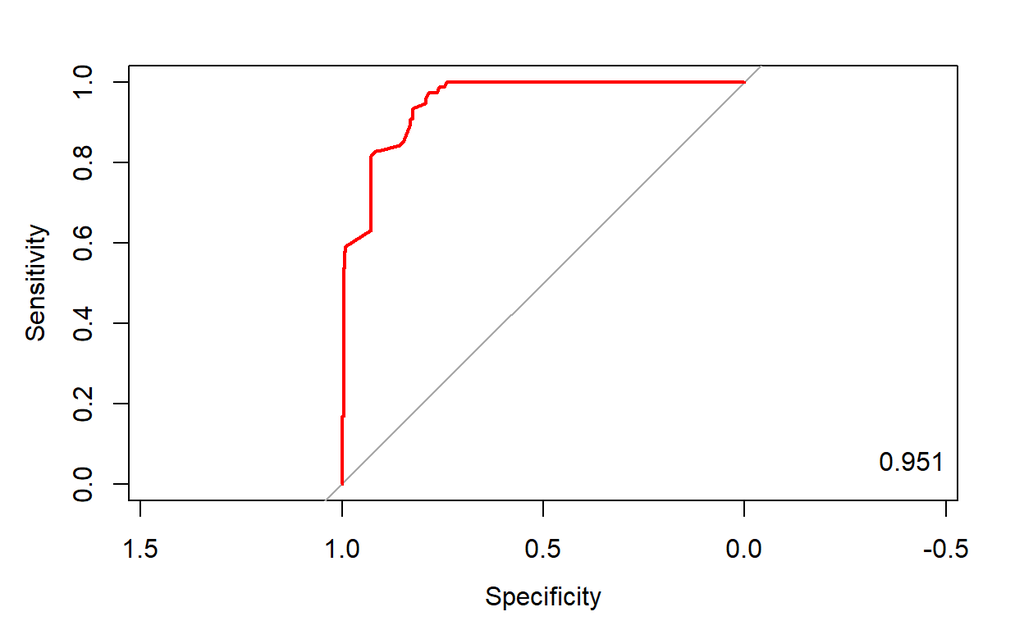

```
pacman::p_load("pROC")

test.ada.prob <- predict(caret.gd.ada, newdata = UB.ted, type = "prob")  # Training Data로 적합시킨 모형에 대한 Test Data의 각 클래스에 대한 예측 확률
test.ada.prob <- test.ada.prob[,2]                                       # "yes"에 대한 예측 확률


ac           <- UB.ted$Personal.Loan                                     # 실제 클래스래스

pp           <- as.numeric(test.ada.prob)                                # "yes"에 대한 예측 확률


ada.roc     <- roc(ac, pp, plot = T, col = "red")                        # roc(실제 클래스, 예측 확률)률)

auc <- round(auc(ada.roc), 3)                                            # AUC
legend("bottomright",legend = auc, bty = "n")
```

```
detach(package:pROC)
```

#### **2) Package “Epi”**

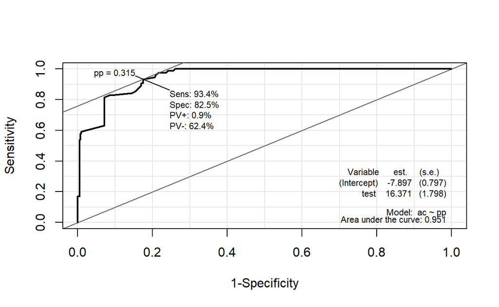

```
pacman::p_load("Epi")
# install_version("etm", version = "1.1", repos = "http://cran.us.r-project.org")

ROC(pp,ac, plot="ROC")       # ROC(예측 확률 , 실제 클래스)
```

```
detach(package:Epi)
```

#### **3) Package “ROCR”**

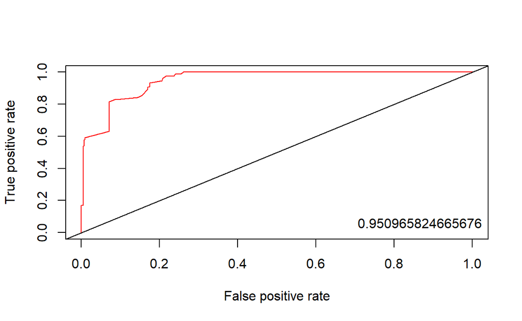

```
pacman::p_load("ROCR")

ada.pred <- prediction(pp, ac)                      # prediction(예측 확률, 실제 클래스)스)

ada.perf <- performance(ada.pred, "tpr", "fpr")     # performance(, "민감도", "1-특이도")
plot(ada.perf, col = "red")                         # ROC Curve
abline(0,1, col = "black")


perf.auc <- performance(ada.pred, "auc")            # AUC

auc <- attributes(perf.auc)$y.values
legend("bottomright",legend = auc,bty = "n")
```

### **3-2-3. 향상 차트**

#### **1) Package “ROCR”**

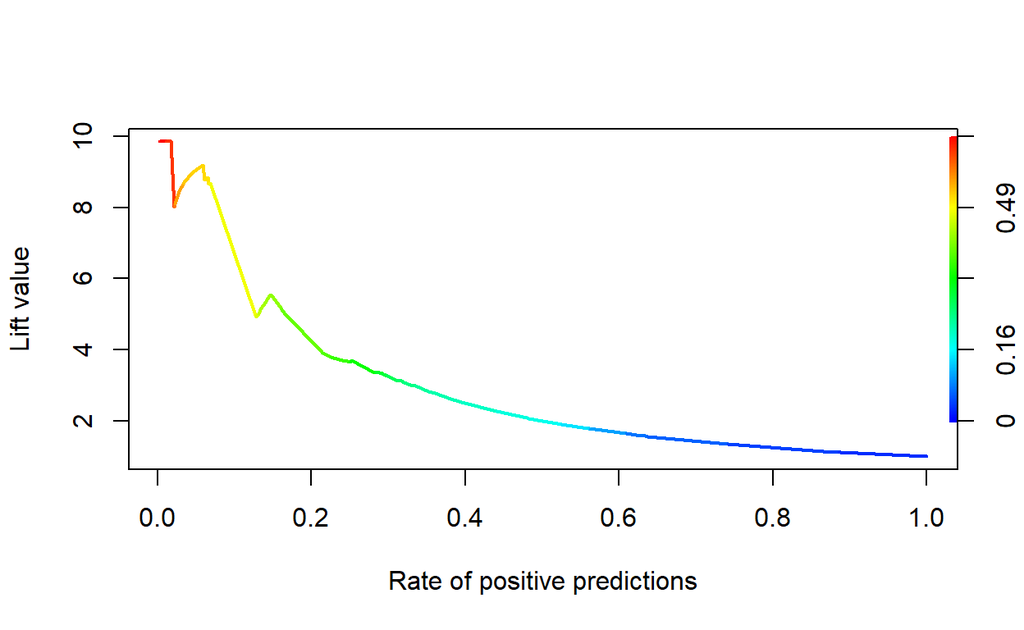

```
ada.lift <- performance(ada.pred,"lift", "rpp")      # Lift chart
plot(ada.lift, colorize = T, lwd = 2)
```

```
detach(package:ROCR)
```

#### **2) Package “lift”**

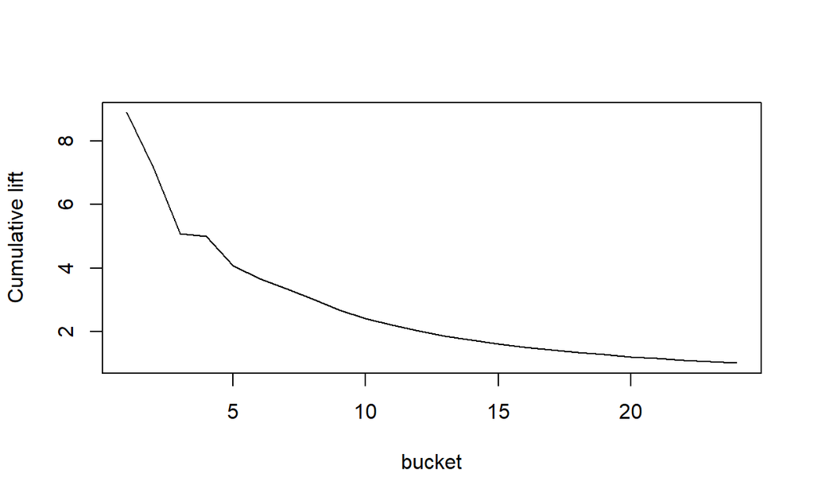

```
pacman::p_load("lift")

ac.numeric <- ifelse(UB.ted$Personal.Loan=="yes",1,0)     # 실제 클래스를 수치형으로 변환 변환

plotLift(pp, ac.numeric, cumulative = T, n.buckets = 24)  # plotLift(예측 확률, 실제 클래스)스)
```

```
TopDecileLift(pp, ac.numeric)                             # Top 10% 향상도 출력
```

```
[1] 5.913
```

```
detach(package:lift)
```

# **4. Gradient Boosting**

## **4-1. 최적의 모수 찾기**

> Boosting에서 가장 많이 쓰이는 Gradient Boosting의 최적의 모수를 찾기 위해서 `"Random Search"` 방법을 먼저 수행하였다.

```
fitControl <- trainControl(method = "cv", number = 5, search = "random")    # 5-Fold-Cross Validation
```

```
set.seed(100)                                                  # seed 고정 For Cross Validation
caret.rd.gbm <- train(Personal.Loan~., data = UB.trd,
                      method = "gbm", trControl = fitControl,
                      tuneLength = 5, verbose=F)               # tuneLength (탐색할 후보 모수 갯수)

caret.rd.gbm
```

```
Stochastic Gradient Boosting

1751 samples
  12 predictor
   2 classes: 'no', 'yes'

No pre-processing
Resampling: Cross-Validated (5 fold)
Summary of sample sizes: 1401, 1401, 1400, 1401, 1401
Resampling results across tuning parameters:

  shrinkage  interaction.depth  n.minobsinnode  n.trees  Accuracy
  0.1235627  6                  22               282     0.9777306
  0.2151574  6                  16              2343     0.9817273
  0.2163256  4                   7              2419     0.9811559
  0.4017440  7                  15              2762     0.9703004
  0.4144840  7                  23              4062     0.9651608
  Kappa
  0.8749167
  0.8980256
  0.8951350
  0.8432471
  0.8159151

Accuracy was used to select the optimal model using the
 largest value.
The final values used for the model were n.trees =
 2343, interaction.depth = 6, shrinkage = 0.2151574
 and n.minobsinnode = 16.
```

- Tune Parameter
  - `n.trees` : 반복 수
  - `interaction.depth` : Tree의 최대 깊이
  - `shrinkage` : Learning Rate
  - `n.minobsinnode` : Terminal node의 최소 관측갯수
- `n.trees` = 2343, `interaction.depth` = 6, `shrinkage` = 0.2151574, `n.minobsinnode` = 16일 때 정확도가 가장 높다.
- `n.trees` = 2343, `interaction.depth` = 6, `shrinkage` = 0.2151574, `n.minobsinnode` = 16을 기준으로 다양한 후보 모수를 주며 `Grid Search` 방법으로 최적의 모수를 찾는다.

[output not shown]

```
set.seed(100)             # seed 고정 For Cross Validation
caret.gd.gbm <- train(Personal.Loan~., data = UB.trd, method = "gbm",
                      trControl = fitControl, tuneGrid = customGrid, verbose=F)

caret.gd.gbm
```

```
Stochastic Gradient Boosting

1751 samples
  12 predictor
   2 classes: 'no', 'yes'

No pre-processing
Resampling: Cross-Validated (5 fold)
Summary of sample sizes: 1401, 1401, 1400, 1401, 1401
Resampling results across tuning parameters:

  shrinkage  interaction.depth  n.minobsinnode  n.trees  Accuracy
  0.21       6                  16              2343     0.9811543
  0.21       6                  16              2344     0.9811543
  0.21       6                  17              2343     0.9805861
  0.21       6                  17              2344     0.9805861
  0.21       7                  16              2343     0.9828702
  0.21       7                  16              2344     0.9828702
  0.21       7                  17              2343     0.9805845
  0.21       7                  17              2344     0.9805845
  0.22       6                  16              2343     0.9817273
  0.22       6                  16              2344     0.9817273
  0.22       6                  17              2343     0.9817289
  0.22       6                  17              2344     0.9817289
  0.22       7                  16              2343     0.9811575
  0.22       7                  16              2344     0.9817289
  0.22       7                  17              2343     0.9817257
  0.22       7                  17              2344     0.9817257
  Kappa
  0.8954993
  0.8954993
  0.8924529
  0.8924529
  0.9042869
  0.9042869
  0.8928468
  0.8928468
  0.8991119
  0.8991119
  0.8983321
  0.8983321
  0.8959374
  0.8992264
  0.8996204
  0.8996204

Accuracy was used to select the optimal model using the
 largest value.
The final values used for the model were n.trees =
 2343, interaction.depth = 7, shrinkage = 0.21 and n.minobsinnode
 = 16.
```

- `n.trees` = 2343, `interaction.depth` = 7, `shrinkage` = 0.21, `n.minobsinnode` = 16일 때 가장 높으며, 정확도는 약간 증가했다.

[output not shown]

```
A gradient boosted model with bernoulli loss function.
2343 iterations were performed.
There were 15 predictors of which 15 had non-zero influence.
```

### **4-1-1. 변수 중요도**

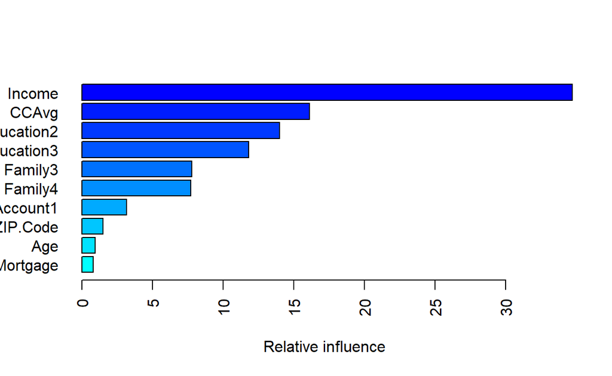

```
                                    var     rel.inf
Income                           Income 34.69765109
CCAvg                             CCAvg 16.09264392
Education2                   Education2 13.99098001
Education3                   Education3 11.81194074
Family3                         Family3  7.77047223
Family4                         Family4  7.70439846
CD.Account1                 CD.Account1  3.15419520
ZIP.Code                       ZIP.Code  1.48241098
Age                                 Age  0.95032101
Mortgage                       Mortgage  0.80482155
Experience                   Experience  0.55690568
Online1                         Online1  0.48191241
CreditCard1                 CreditCard1  0.28222266
Family2                         Family2  0.14886186
Securities.Account1 Securities.Account1  0.07026221
```

```
summary(caret.gd.gbm$finalModel, cBars = 10, las=2)         # cBars : 상위 몇개 나타낼 것인지
```

## **4-2. 모형 평가**

[output not shown]

### **4-2-1. ConfusionMatrix**

```
confusionMatrix(caret.gd.gbm.pred, UB.ted$Personal.Loan, positive = "yes")  # confusionMatrix(예측 클래스, 실제 클래스, positive = "관심 클래스") 클래스")
```

```
Confusion Matrix and Statistics

          Reference
Prediction  no yes
       no  669  12
       yes   4  64

               Accuracy : 0.9786
                 95% CI : (0.9655, 0.9877)
    No Information Rate : 0.8985
    P-Value [Acc > NIR] : < 2e-16

                  Kappa : 0.8771

 Mcnemar's Test P-Value : 0.08012

            Sensitivity : 0.84211
            Specificity : 0.99406
         Pos Pred Value : 0.94118
         Neg Pred Value : 0.98238
             Prevalence : 0.10147
         Detection Rate : 0.08545
   Detection Prevalence : 0.09079
      Balanced Accuracy : 0.91808

       'Positive' Class : yes
```

### **4-2-2. ROC 곡선**

#### **1) Package “pROC”**

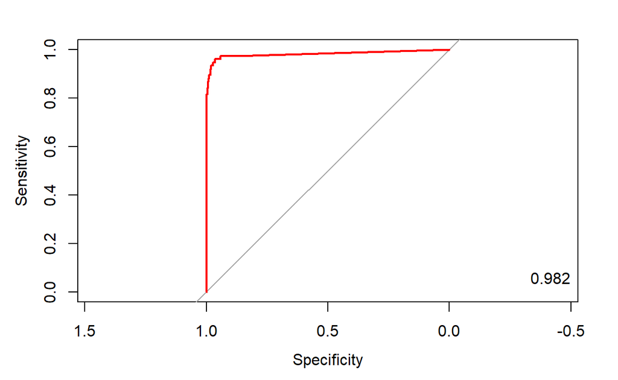

```
pacman::p_load("pROC")

test.gbm.prob <- predict(caret.gd.gbm, newdata = UB.ted, type = "prob")  # Training Data로 적합시킨 모형에 대한 Test Data의 각 클래스에 대한 예측 확률
test.gbm.prob <- test.gbm.prob[,2]                                       # "yes"에 대한 예측 확률


ac           <- UB.ted$Personal.Loan                                     # 실제 클래스래스

pp           <- as.numeric(test.gbm.prob)                                # "yes"에 대한 예측 확률


gbm.roc      <- roc(ac, pp, plot = T, col = "red")                       # roc(실제 클래스, 예측 확률)률)

auc          <- round(auc(gbm.roc), 3)                                   # AUC
legend("bottomright",legend = auc, bty = "n")
```

```
detach(package:pROC)
```

#### **2) Package “Epi”**

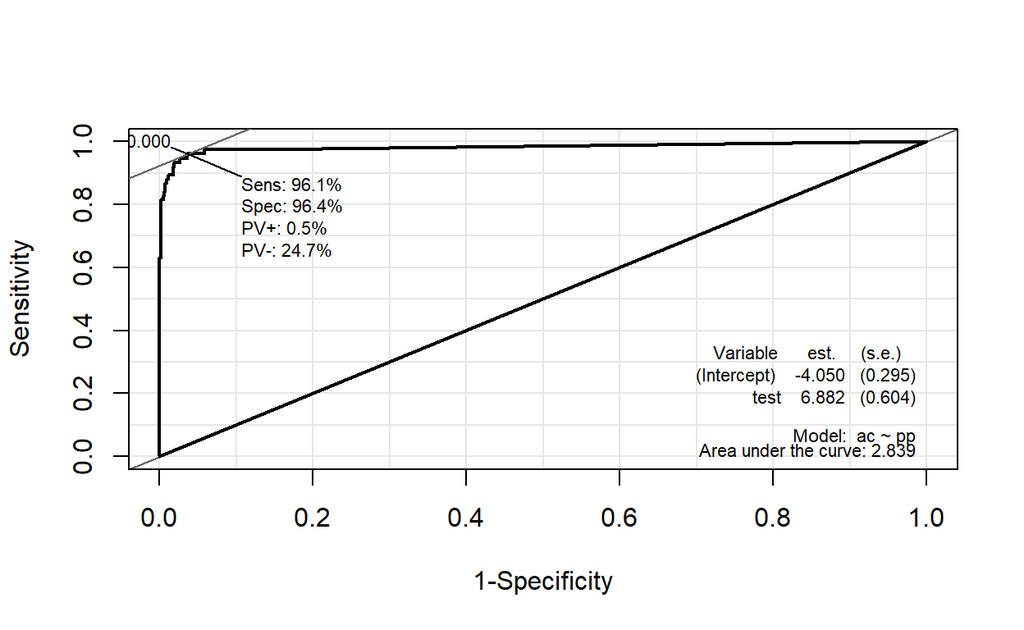

```
pacman::p_load("Epi")
# install_version("etm", version = "1.1", repos = "http://cran.us.r-project.org")

ROC(pp,ac, plot="ROC")       # ROC(예측 확률 , 실제 클래스)
```

```
detach(package:Epi)
```

#### **3) Package “ROCR”**

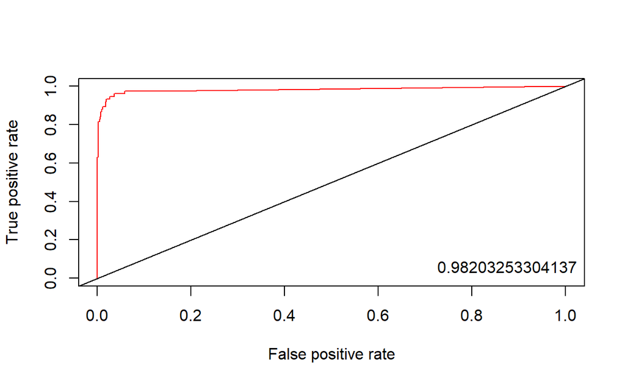

```
pacman::p_load("ROCR")

gbm.pred <- prediction(pp, ac)                      # prediction(예측 확률, 실제 클래스)스)

gbm.perf <- performance(gbm.pred, "tpr", "fpr")     # performance(, "민감도", "1-특이도")
plot(gbm.perf, col="red")                           # ROC Curve
abline(0,1, col="black")


perf.auc <- performance(gbm.pred, "auc")            # AUC

auc <- attributes(perf.auc)$y.values
legend("bottomright",legend = auc,bty = "n")
```

### **4-2-3. 향상 차트**

#### **1) Package “ROCR”**

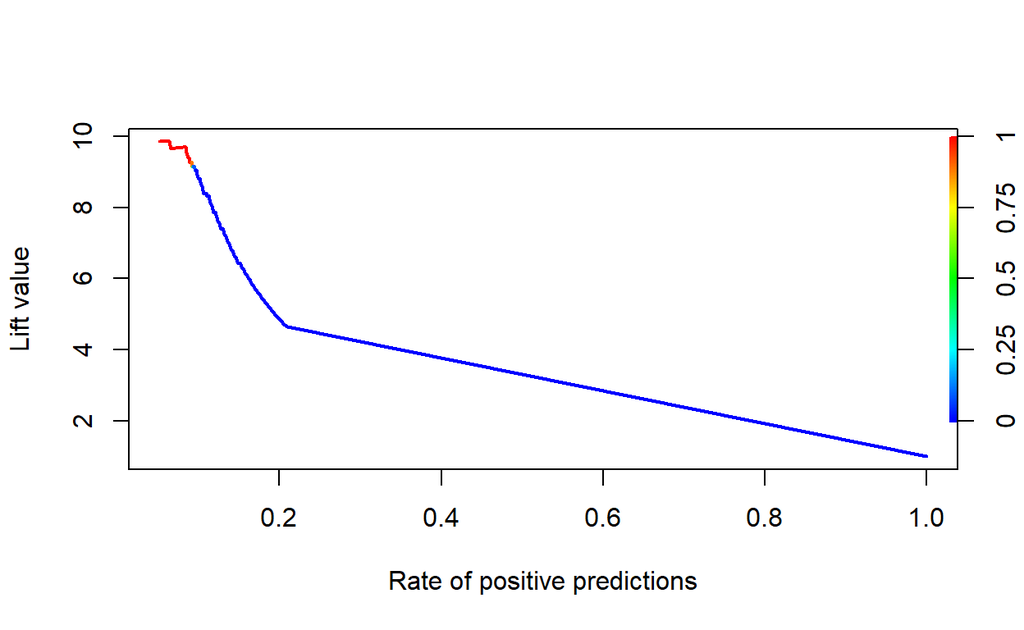

```
gbm.lift <- performance(gbm.pred,"lift", "rpp")      # Lift chart
plot(gbm.lift, colorize = T, lwd = 2)
```

```
detach(package:ROCR)
```

#### **2) Package “lift”**

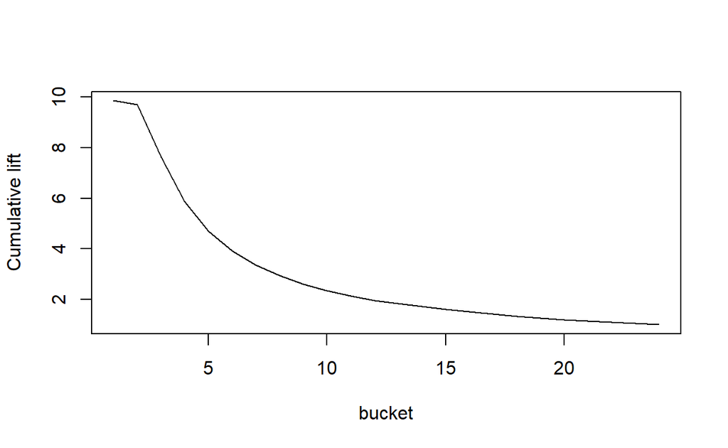

```
pacman::p_load("lift")

ac.numeric <- ifelse(UB.ted$Personal.Loan=="yes",1,0)     # 실제 클래스를 수치형으로 변환 변환

plotLift(pp, ac.numeric, cumulative = T, n.buckets =24)   # plotLift(예측 확률, 실제 클래스)스)
```

```
TopDecileLift(pp, ac.numeric)                             # Top 10% 향상도 출력
```

```
[1] 8.804
```

```
detach(package:lift)
```

# **5. XGBoost**

## **5-1. 최적의 모수 찾기**

> Gradient Boosting에서 확장된 XGBoost의 최적의 모수를 찾기 위해서 `"Random Search"` 방법을 먼저 수행하였다.

```
fitControl <- trainControl(method = "cv", number = 5, search = "random")    # 5-Fold-Cross Validation
```

```
set.seed(100)                                                      # seed 고정 For Cross Validation
caret.rd.xgb <- train(Personal.Loan~., data = UB.trd,
                      method = "xgbTree", trControl = fitControl,
                      tuneLength = 5,                              # tuneLength (탐색할 후보 모수 갯수)
                      lambda = 0)                                  # Regularization Parameter

caret.rd.xgb
```

```
eXtreme Gradient Boosting

1751 samples
  12 predictor
   2 classes: 'no', 'yes'

No pre-processing
Resampling: Cross-Validated (5 fold)
Summary of sample sizes: 1401, 1401, 1400, 1401, 1401
Resampling results across tuning parameters:

  eta        max_depth  gamma     colsample_bytree  min_child_weight
  0.1235627  6          7.108038  0.6081206         18
  0.2151574  6          5.383487  0.6527814          3
  0.2163256  4          7.489722  0.5196387          3
  0.3219509  6          1.714202  0.4953224         15
  0.4144840  7          4.201015  0.4110895         19
  subsample  nrounds  Accuracy   Kappa
  0.7220431  358      0.9371803  0.5812145
  0.9921731  624      0.9811608  0.8921203
  0.3477167  985      0.9697354  0.8184426
  0.8988404  919      0.9623118  0.7734267
  0.4979954  718      0.8989109  0.3717268

Accuracy was used to select the optimal model using the
 largest value.
The final values used for the model were nrounds = 624, max_depth
 = 6, eta = 0.2151574, gamma = 5.383487, colsample_bytree
 = 0.6527814, min_child_weight = 3 and subsample = 0.9921731.
```

- Tune Parameter
  - `nrounds` : 반복 수
  - `max_depth` : Tree의 최대 깊이
  - `eta` : Learning Late
  - `gamma` : 분할하기 위해 필요한 최소 손실 감소, 클수록 분할이 쉽게 일어나지 않음
  - `colsample_bytree` : Tree 생성 때 사용할 예측변수 비율
  - `min_child_weight` : 한 leaf 노드에 요구되는 관측치에 대한 가중치의 최소 합
  - `subsample` : 모델 구축시 사용할 Data비율로 1이면 전체 Data 사용
- `nrounds` = 624, `max_depth` = 6, `eta` = 0.2151574, `gamma` = 5.383487, `colsample_bytree` = 0.6527814, `min_child_weight` = 3, `subsample` = 0.9921731일 때 정확도가 가장 높다.
- `nrounds` = 624, `max_depth` = 6, `eta` = 0.2151574, `gamma` = 5.383487, `colsample_bytree` = 0.6527814, `min_child_weight` = 3, `subsample` = 0.9921731을 기준으로 다양한 후보 모수를 주며 `Grid Search` 방법으로 최적의 모수를 찾는다.

[output not shown]

```
set.seed(100)                                                              # seed 고정 For Cross Validation
caret.gd.xgb <- train(Personal.Loan~., data = UB.trd, method = "xgbTree",
                      trControl = fitControl, tuneGrid = customGrid,
                      lambda = 0)                                          # Regularization Parameter

caret.gd.xgb
```

```
eXtreme Gradient Boosting

1751 samples
  12 predictor
   2 classes: 'no', 'yes'

No pre-processing
Resampling: Cross-Validated (5 fold)
Summary of sample sizes: 1401, 1401, 1400, 1401, 1401
Resampling results across tuning parameters:

  eta  max_depth  gamma  colsample_bytree  min_child_weight
  0.2  6          5.3    0.6               3
  0.2  6          5.3    0.6               3
  0.2  6          5.3    0.6               3
  0.2  6          5.3    0.6               3
  0.2  6          5.3    0.6               4
  0.2  6          5.3    0.6               4
  0.2  6          5.3    0.6               4
  0.2  6          5.3    0.6               4
  0.2  6          5.3    0.7               3
  0.2  6          5.3    0.7               3
  0.2  6          5.3    0.7               3
  0.2  6          5.3    0.7               3
  0.2  6          5.3    0.7               4
  0.2  6          5.3    0.7               4
  0.2  6          5.3    0.7               4
  0.2  6          5.3    0.7               4
  0.2  6          5.4    0.6               3
  0.2  6          5.4    0.6               3
  0.2  6          5.4    0.6               3
  0.2  6          5.4    0.6               3
  0.2  6          5.4    0.6               4
  0.2  6          5.4    0.6               4
  0.2  6          5.4    0.6               4
  0.2  6          5.4    0.6               4
  0.2  6          5.4    0.7               3
  0.2  6          5.4    0.7               3
  0.2  6          5.4    0.7               3
  0.2  6          5.4    0.7               3
```

[output cut: 220 more lines]

```
  1.0        625      0.9777354  0.8710367
  0.9        624      0.9811608  0.8926377
  0.9        625      0.9811608  0.8926377
  1.0        624      0.9777338  0.8704176
  1.0        625      0.9777338  0.8704176
  0.9        624      0.9817338  0.8954059
  0.9        625      0.9811624  0.8920340
  1.0        624      0.9800179  0.8852626
  1.0        625      0.9800179  0.8852626

Accuracy was used to select the optimal model using the
 largest value.
The final values used for the model were nrounds = 624, max_depth
 = 7, eta = 0.3, gamma = 5.3, colsample_bytree =
 0.7, min_child_weight = 3 and subsample = 1.
```

- `nrounds` = 624, `max_depth` = 7, `eta` = 0.3, `gamma` = 5.3, `colsample_bytree` = 0.7, `min_child_weight` = 3, `subsample` = 1일 때 가장 높다.

### **5-1-1. 변수 중요도**

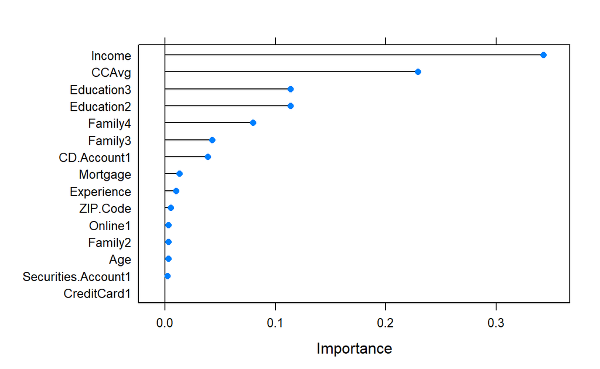

```
xgbImp <- varImp(caret.gd.xgb, scale = FALSE)
plot(xgbImp)
```

## **5-2. 모형 평가**

[output not shown]

### **5-2-1. ConfusionMatrix**

```
confusionMatrix(caret.gd.xgb.pred, UB.ted$Personal.Loan, positive = "yes")  # confusionMatrix(예측 클래스, 실제 클래스, positive = "관심 클래스") 클래스")
```

```
Confusion Matrix and Statistics

          Reference
Prediction  no yes
       no  670  12
       yes   3  64

               Accuracy : 0.98
                 95% CI : (0.9672, 0.9887)
    No Information Rate : 0.8985
    P-Value [Acc > NIR] : < 2e-16

                  Kappa : 0.8841

 Mcnemar's Test P-Value : 0.03887

            Sensitivity : 0.84211
            Specificity : 0.99554
         Pos Pred Value : 0.95522
         Neg Pred Value : 0.98240
             Prevalence : 0.10147
         Detection Rate : 0.08545
   Detection Prevalence : 0.08945
      Balanced Accuracy : 0.91882

       'Positive' Class : yes
```

### **5-2-2. ROC 곡선**

#### **1) Package “pROC”**

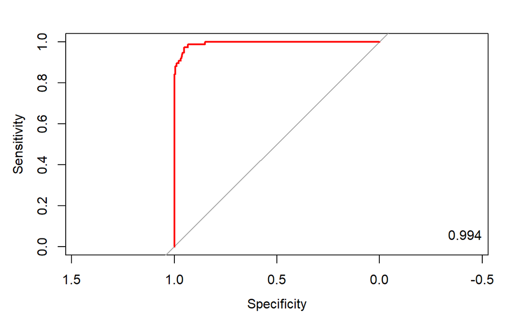

```
pacman::p_load("pROC")

test.xgb.prob <- predict(caret.gd.xgb, newdata = UB.ted, type = "prob")  # Training Data로 적합시킨 모형에 대한 Test Data의 각 클래스에 대한 예측 확률
test.xgb.prob <- test.xgb.prob[,2]                                       # "yes"에 대한 예측 확률


ac           <- UB.ted$Personal.Loan                                     # 실제 클래스래스

pp           <- as.numeric(test.xgb.prob)                                # "yes"에 대한 예측 확률


xgb.roc      <- roc(ac, pp, plot = T, col = "red")                       # roc(실제 클래스, 예측 확률)률)

auc          <- round(auc(xgb.roc), 3)                                   # AUC
legend("bottomright",legend = auc, bty = "n")
```

```
detach(package:pROC)
```

#### **2) Package “Epi”**

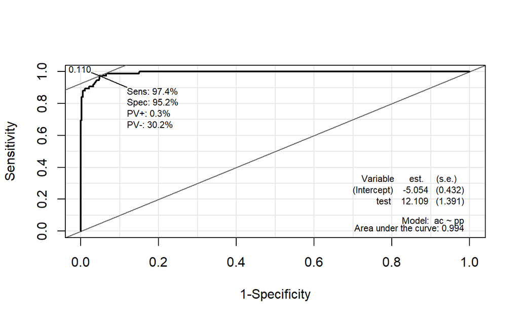

```
pacman::p_load("Epi")
# install_version("etm", version = "1.1", repos = "http://cran.us.r-project.org")

ROC(pp,ac, plot="ROC")       # ROC(예측 확률 , 실제 클래스)
```

```
detach(package:Epi)
```

#### **3) Package “ROCR”**

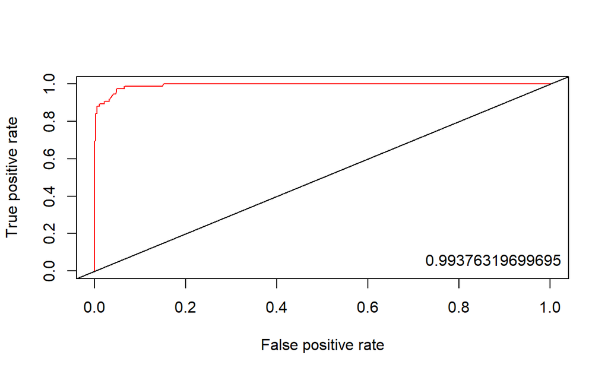

```
pacman::p_load("ROCR")

xgb.pred <- prediction(pp, ac)                      # prediction(예측 확률, 실제 클래스)스)

xgb.perf <- performance(xgb.pred, "tpr", "fpr")     # performance(, "민감도", "1-특이도")
plot(xgb.perf, col = "red")                         # ROC Curve
abline(0,1, col = "black")


perf.auc <- performance(xgb.pred, "auc")            # AUC

auc <- attributes(perf.auc)$y.values
legend("bottomright",legend = auc,bty = "n")
```

### **5-2-3. 향상 차트**

#### **1) Package “ROCR”**

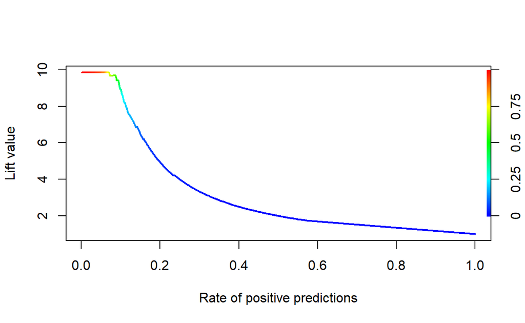

```
xgb.lift <- performance(xgb.pred,"lift", "rpp")      # Lift chart
plot(xgb.lift, colorize = T, lwd = 2)
```

```
detach(package:ROCR)
```

#### **2) Package “lift”**

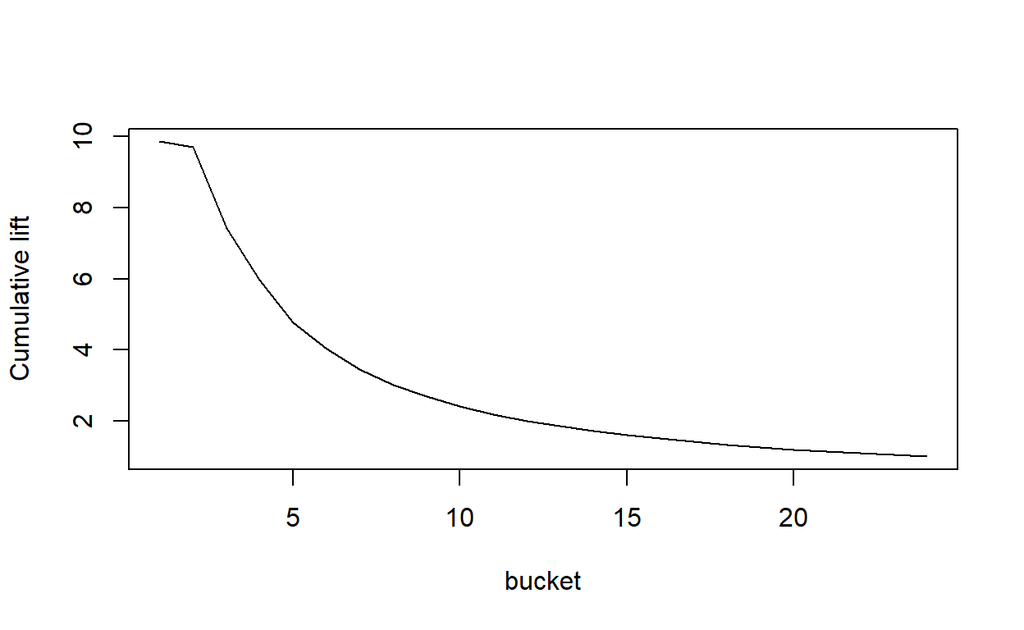

```
pacman::p_load("lift")

ac.numeric <- ifelse(UB.ted$Personal.Loan=="yes",1,0)     # 실제 클래스를 수치형으로 변환 변환

plotLift(pp, ac.numeric, cumulative = T, n.buckets = 24)  # plotLift(예측 확률, 실제 클래스)스)
```

```
TopDecileLift(pp, ac.numeric)                             # Top 10% 향상도 출력
```

```
[1] 8.935
```

```
detach(package:lift)
```

# **6. 모형 비교**

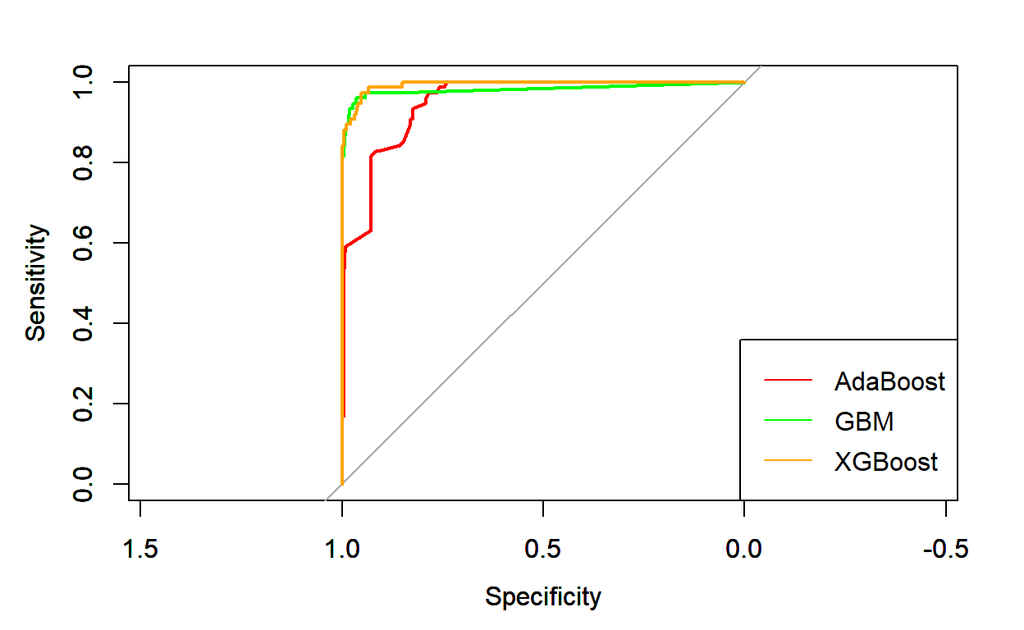

```
plot(ada.roc, col="red")         # ROC Curve
par(new=TRUE)
plot(gbm.roc, col="green")       # ROC Curve
par(new=TRUE)
plot(xgb.roc, col="orange")      # ROC Curve

legend("bottomright", legend=c( "AdaBoost", "GBM", "XGBoost" ),
       col=c( "red", "green", "orange"), lty=c(1,1,1))
```